# Part II - Investigating Factors that Increases Ride Duration for Ford Gobike

## By Leleji Godwin Lucky

## Investigation Overview

> The amount of time used for each bike share trip determines the amount of profit we add as a company. Longer ride durations translate automatically to more money and vice-versa. To drive growth, we must explore those factors that makes our Customers spend more time for the trip. In this investigation, my objective to was to investigate those factors increases the ride duration for each trip.

## Dataset Overview

> This particular dataset contains information of Bike Share trips collected in February of 2019. It initially consists of 183412 trips. I dropped some features that I considered irrelevant to the current analysis such as location information. Additionally, I engineered new features that I considered necessary to the anlaysis from existing features. At the end of the wrangling stage, I had 167,424 enteries with 9 variables or columns.

## Variables Used in the Analysis

- ride_duration (mins.): the duration in minutes for each ride.
- start_stattion_name: the name of the start station.
- end_station_name: the name of the end station.
- user_type (Customer or Subscriber): subscription status of each user. Users could subscribe to the service or Customers.

## Variables Used in the Analysis Contd.

- riders_age (int): the age of the Rider.
- member_gender: gender of the Rider.
- bike_share_for_all_trip: indicates if the Rider is enrolled in the Bike Share for All program
- start_wwekday: the day of the week the bike was hired.
- time_of_day: the hour of the day the bike was hired.

## Dependent Variable

The dependent variable in this analysis is the ride duration.

## Distribution of Ride Duration

> The histogram below has been plotted on a logarithmic scale. This is necessary to capture the information in our data due to the range of the ride duration.

> Ride durations are typically between 4 and 30 minutes. In our dataset, we had values on both ends of this interval. Some rides are as low as a minute and some are well over a thousand minutes!

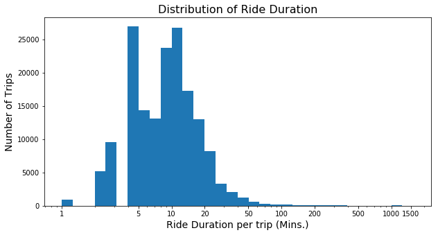

## Distribution of User Types

There are almost 10x more Subscribers than Customers using the service in February of 2019.

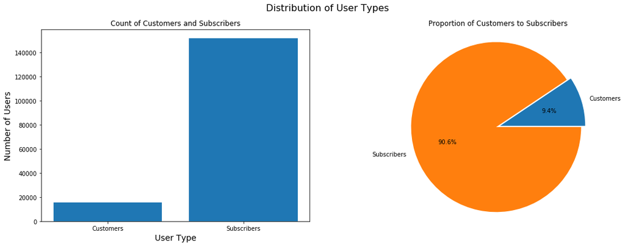

## Daily Distribution of Trips Organized by User Type

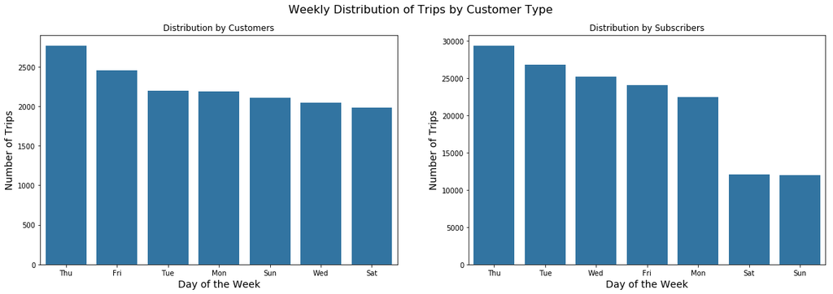

## Hourly Distribution of Trips

With almost 20,000 trips each, 8am and 5pm are the peak hours for bike share services. These peak times also have plus or minus one hour where there are massive amounts bike share trips.

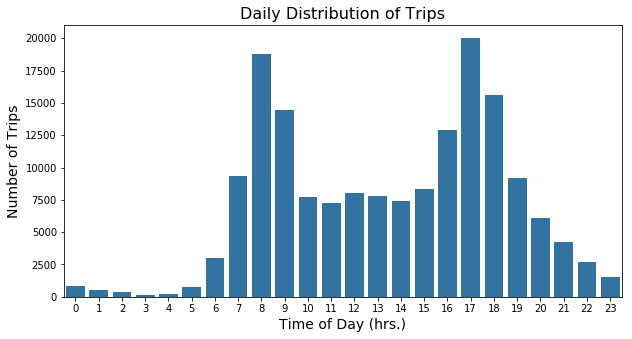

## Smaller Numbers; Longer Rides

> Although there are about 10x more Subscribers than Customers, the heatmap below shows us that the smaller numbers makes the longer rides.

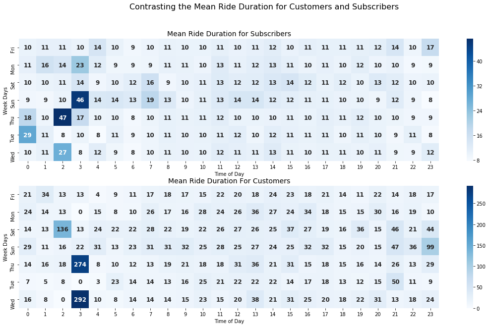

## Commuters or Fun Seekers?

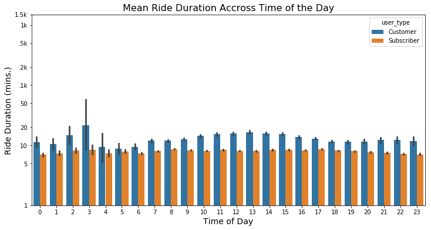

## Make More Cycling Hobbyists!

> The chart below summarizes the key findings from this investigation. The major factor that influences and increases ride duration is the purpose to which the service is put. Commuters will obviously prefer to pay a subscription fee simply because they use the service daily, however, their ride durations are painfully very short.

> The key to making more people spend more time riding bikes is to make more cycling hobbyists, attract more people Tourists and encourage Recreational Cycling.

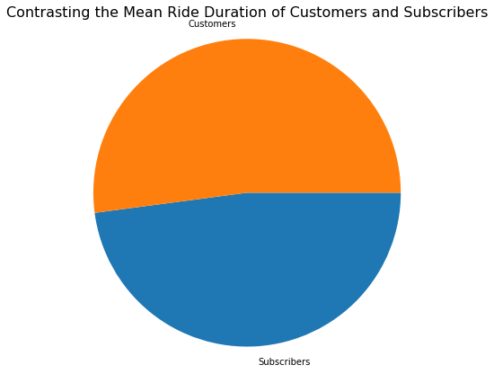